# Multi-Objective Optimization

# Multi-Objective Evolutionary Algorithms

Today

1. Dominance and Pareto Optimality
2. Multi-Objective Evolutionary Algorithms
3. A Toy ε-MOEA on ZDT1
4. Reading and Using the Pareto Front
5. Wrapup

## How MOEAs Work

- Maintain a **population** of candidate solutions that evolves over generations
- **Selection** favors non-dominated solutions
- **Diversity preservation** spreads solutions across the front
- Repeat until convergence

Result: a set of solutions approximating the full trade-off curve, including non-convex regions.

## Genetic Algorithm Mechanics

A GA is stochastic search with a **population** instead of a single point.

- **Population**: $N$ candidate solutions in the decision space
- **Evaluation**: compute objectives for every member
- **Selection**: bias future generations toward better solutions
- **Variation**: produce offspring via *crossover* (mix two parents) and *mutation* (perturb)
- **Replacement**: combine parents + offspring, keep the best $N$
- Repeat for many generations

The population is what makes GAs natural for MOO: many trade-off points evolve at once.

## ε-Dominance

**Why we need it.** Plain Pareto dominance has two practical problems:

- **Diversity.** Nothing stops the archive from clustering many near-identical solutions in one region of the front while leaving other regions empty.
- **Computation.** The archive can grow without bound — every slightly-different point survives — and every new candidate must be checked against all of them.

We want a rule that keeps only solutions that differ by amounts the decision-maker actually cares about.

## ε-Boxes

Pick a vector $\boldsymbol\epsilon = (\epsilon_1, \ldots, \epsilon_k)$ — one resolution per objective. Tile objective space with boxes of side $\epsilon_i$ along axis $i$, and map each solution to the integer coordinates of the box it lands in.

**ε-dominance:** $a$ ε-dominates $b$ if $a$’s box dominates $b$’s box in the ordinary sense, *and* the archive keeps **at most one solution per box**.

- Two solutions in the same box are treated as equivalent — keep the one closer to the box’s lower corner
- $\epsilon_i$ encodes the resolution at which the decision-maker cares about differences on objective $i$
- Resolutions can differ by objective (e.g., damages in $M, lives in counts)
- Archive size is bounded by the number of boxes the front intersects

## ε-Dominance: Picture

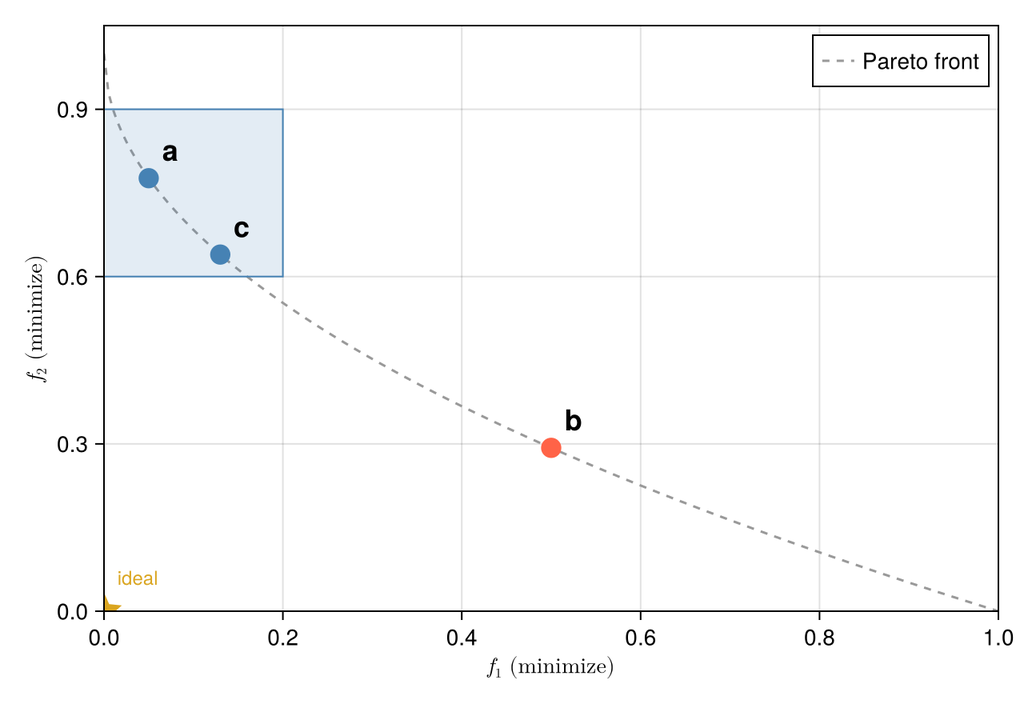

Figure 3: An $\epsilon$-grid with $\epsilon_1 = 0.20$, $\epsilon_2 = 0.30$. Points $a$ and $c$ both fall in the same box, so the archive keeps only one (whichever is closer to the box’s lower corner). Point $b$ lives in a different box and survives. The star marks the (infeasible) ideal point.

# A Toy ε-MOEA on ZDT1

Today

1. Dominance and Pareto Optimality
2. Multi-Objective Evolutionary Algorithms
3. A Toy ε-MOEA on ZDT1
4. Reading and Using the Pareto Front
5. Wrapup

## ZDT1: A Test Problem

A standard MOO benchmark with two decision variables $x_1, x_2 \in [0, 1]$ and two objectives (both minimized):

$$\begin{align*}
f_1 &= x_1 \\
f_2 &= g(x_2)\left(1 - \sqrt{f_1 / g(x_2)}\right) \\
g(x_2) &= 1 + 9 x_2
\end{align*}$$

The analytical Pareto front is $x_2 = 0$, giving $f_2 = 1 - \sqrt{f_1}$ on $f_1 \in [0, 1]$.

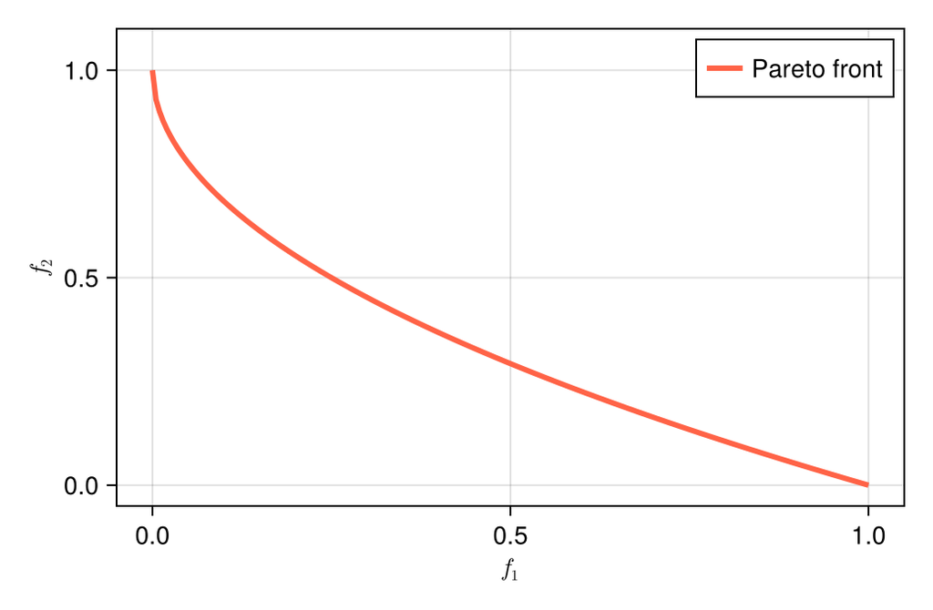

Figure 4: Canonical visualization of ZDT1: the analytical Pareto front in objective space.

```julia
using Random
Random.seed!(1)

function zdt1(x)
    f1 = x[1]
    g = 1 + 9 * x[2]
    f2 = g * (1 - sqrt(f1 / g))
    return [f1, f2]
end

let
    fs = 0.0:0.005:1.0
    fig = Figure(; size=(520, 340))
    ax = Axis(fig[1, 1]; xlabel=L"f_1", ylabel=L"f_2",
        limits=(-0.05, 1.05, -0.05, 1.1))
    lines!(ax, fs, 1 .- sqrt.(fs); color=:tomato, linewidth=3,
        label="Pareto front")
    axislegend(ax; position=:rt)
    fig
end
```

## Mutation

The GA’s source of new points: take a parent vector, add small Gaussian noise, clamp back into the unit box.

```julia
mutate(x) = clamp.(x .+ 0.1 .* randn(length(x)), 0, 1)
```

## ε-Dominance in Code

Map each point to its $\epsilon$-box, then apply ordinary dominance on the integer box coordinates.

```julia
# Integer coordinates of the ε-box a point lands in
ebox(f, ε) = floor.(Int, f ./ ε)

# a ε-dominates b if a's box dominates b's box
function eps_dominates(a, b, ε)
    ba, bb = ebox(a, ε), ebox(b, ε)
    return all(ba .<= bb) && any(ba .< bb)
end
```

- `floor.(Int, f ./ ε)` is the entire ε-grid mapping
- Dominance on integer tuples is the same comparison from the dominance slides — just at coarser resolution

## Archive Update

```julia
function update_archive!(archive, cand, ε)
    cb = ebox(cand.f, ε)
    drop = Int[]
    for (i, m) in enumerate(archive)
        mb = ebox(m.f, ε)
        if mb == cb
            # Same box: keep whichever is closer to its lower corner
            if sum((m.f .- mb .* ε) .^ 2) <= sum((cand.f .- cb .* ε) .^ 2)
                return
            else
                push!(drop, i)
            end
        elseif eps_dominates(m.f, cand.f, ε)
            return                           # candidate ε-dominated by m
        elseif eps_dominates(cand.f, m.f, ε)
            push!(drop, i)                   # candidate ε-dominates m
        end
    end
    deleteat!(archive, drop)
    push!(archive, cand)
    return
end
```

## Initialize

```julia
N = 40
ε = [0.05, 0.05]

pop = [(x=rand(2), f=zeros(2)) for _ in 1:N]
pop = [(x=p.x, f=zdt1(p.x)) for p in pop]

archive = eltype(pop)[]
for p in pop
    update_archive!(archive, p, ε)
end
length(archive)
```

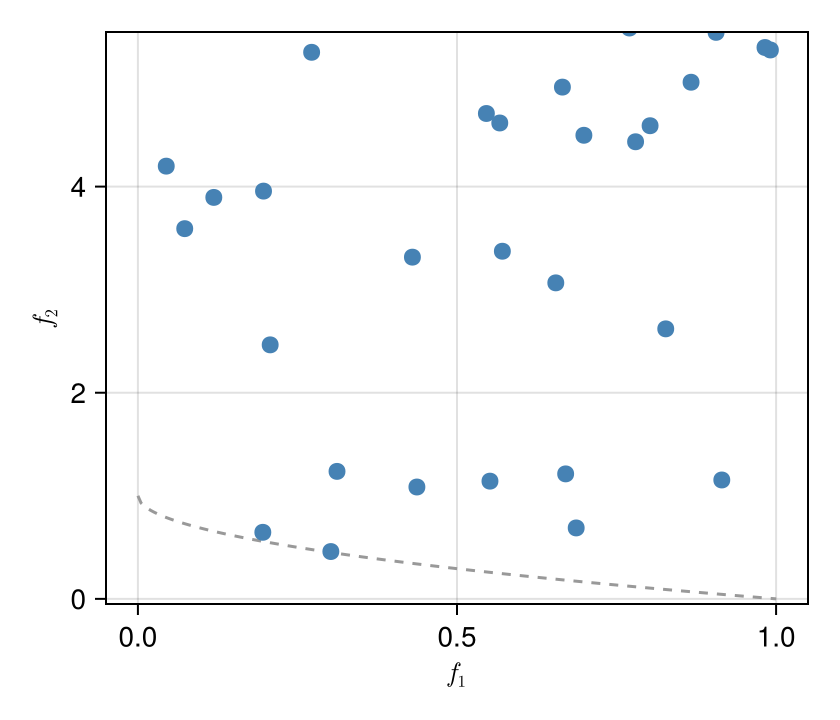

Figure 5: Initial population (blue) vs. analytical front (dashed).

## Running the Model

```julia
function step!(pop, archive, ε; p_random=0.3)
    offspring = map(1:length(pop)) do _
        x = rand() < p_random ? rand(2) : mutate(rand(pop).x)
        (x=x, f=zdt1(x))
    end
    for o in offspring
        update_archive!(archive, o, ε)
    end
    # Next generation: half from archive (exploit), half from offspring (explore)
    half = length(pop) ÷ 2
    return vcat(
        [archive[rand(1:length(archive))] for _ in 1:half],
        offspring[1:(length(pop) - half)],
    )
end
```

```julia
gens = 50
# Frame 0: the raw initial random population (before any selection)
snapshots = Vector{Vector{Point2f}}()
push!(snapshots, [Point2f(p.f...) for p in pop])
# Frames 1..gens: archive after each generation
for g in 1:gens
    global pop = step!(pop, archive, ε)
    push!(snapshots, [Point2f(m.f...) for m in archive])
end
```

## Watching It Converge

[figure not shown]

# Reading and Using the Pareto Front

Today

1. Dominance and Pareto Optimality
2. Multi-Objective Evolutionary Algorithms
3. A Toy ε-MOEA on ZDT1
4. Reading and Using the Pareto Front
5. Wrapup

## What Does Many-Objective Look Like?

With 2 objectives: a curve.

With 3+ objectives: a surface — impossible to visualize directly.

**Parallel axis plots** show all objectives simultaneously. Each line = one non-dominated solution.

[figure not shown]

Figure 6: Parallel axis plot of non-dominated solutions across six objectives. Source: Kasprzyk et al. (2013)

## Reading a Pareto Front

On a Pareto front plot, each axis is one objective and each point is a non-dominated solution.

**The “knee” of the front:**

- Region of high curvature — large gains on one objective for small losses on another
- Often a practical default if no strong preference exists
- Not always present; depends on problem structure

## How Many Objectives?

More objectives → richer representation, but real costs:

- **Computational:** exponentially more solutions to cover the front
- **Conceptual:** harder to reason about trade-offs in high dimensions
- **Communication:** harder to show decision-makers

**Rule of thumb:** use as few objectives as possible. Combining objectives is often the right call — *when the assumptions hold*.

# Wrapup

Today

1. Dominance and Pareto Optimality
2. Multi-Objective Evolutionary Algorithms
3. A Toy ε-MOEA on ZDT1
4. Reading and Using the Pareto Front
5. Wrapup

## Summary

- **Why MOO?** When objectives are incommensurable, weighting hides value choices. MOO keeps them separate.
- **Dominance** is the comparison rule: better on all, strictly better on one. The non-dominated set is the **Pareto front**.
- **MOEAs** approximate the front with a population of designs, dominance-based selection, and variation operators. No gradients needed.
- **$\epsilon$-dominance** thins the archive to a manageable, decision-relevant resolution.
- **Division of labor:** analysts find the front; decision-makers choose from it.

## Looking Ahead

**This week:**

- Wednesday: Madison leads discussion of Yang et al. (2023) — come prepared to discuss objectives, algorithm choice, and how results inform decisions
- Friday: Lab 10 — generate and visualize Pareto fronts for the house elevation problem
- Friday: **Memo 2 due** (Evidence & Robustness)

**Week 13 (Monday):** Putting it all together — how robustness, scenario discovery, sequential decisions, and multi-objective optimization connect in real projects.

## References

Kasprzyk, J. R., Nataraj, S., Reed, P. M., & Lempert, R. J. (2013). Many objective robust decision making for complex environmental systems undergoing change. *Environmental Modelling & Software*, *42*, 55–71. https://doi.org/10.1016/j.envsoft.2012.12.007

Smith, S., Southerby, M., Setiniyaz, S., Apsimon, R., & Burt, G. (2022). Multiobjective optimization and Pareto front visualization techniques applied to normal conducting rf accelerating structures. *Physical Review Accelerators and Beams*, *25*(6), 062002. https://doi.org/10.1103/PhysRevAccelBeams.25.062002

Yang, S., Ruangpan, L., Torres, A. S., & Vojinovic, Z. (2023). Multi-objective Optimisation Framework for Assessment of Trade-Offs between Benefits and Co-benefits of Nature-based Solutions. *Water Resources Management*, *37*(6–7), 2325–2345. https://doi.org/10.1007/s11269-023-03470-8